# Investigate - European Soccer Database

- Introduction
- Data Wrangling
- Exploratory Data Analysis
- Conclusions

## Introduction

### Dataset Description

> This data set contains European Soccer Database for season 2008 to 2016, you can download the data from [here](https://www.kaggle.com/hugomathien/soccer).
- +25,000 matches
- +10,000 players
- 11 European Countries with their lead championship
- Seasons 2008 to 2016
- Players and Teams' attributes* sourced from EA Sports' FIFA video game series, - including the weekly updates
- Team line up with squad formation (X, Y coordinates)
- Betting odds from up to 10 providers
- Detailed match events (goal types, possession, corner, cross, fouls, cards - etc…) for +10,000 matches

```python
# import important library
import numpy as np
import pandas as pd
import matplotlib.pyplot as plt
import seaborn as sns
%matplotlib inline
plt.style.use('ggplot')
```

#### Upload all (7) data sets

```python
# read all data using pandas
df1_country = pd.read_csv("Country.csv")
df2_league = pd.read_csv("League.csv")
df3_match = pd.read_csv("Match.csv")
df4_player = pd.read_csv("Player.csv")
df5_player_att = pd.read_csv("Player_Attributes.csv")
df6_team = pd.read_csv("Team.csv")
df7_team_att = pd.read_csv("Team_Attributes.csv")
```

## Process [1] Understand each table

- Show sample table for each dataset.
- Number of samples in each dataset.
- Number of columns in each dataset.
- Count duplicate rows in each dataset.
- Datatypes of columns.
- Count of missing values.
- Number of unique values for features in each dataset.

### Explore Tables

- Using these methods ( head, shape, info, duplicated, isnull, nunique)

```python
# make a function that takes a dataframe, the name and returns ( head, shape, info, duplicated, isnull, nunique)

def get_info(data,name):
    print("\n-----------------------------------------------------")
    print("The table of>>>",name)
    print(data.head(2))
    print("\n---------------------------------------------------\n")
    print("Rows and columns>>>")
    print(data.shape)
    print("\n---------------------------------------------------\n")
    print("Data types of the data>>>")
    print(data.info())
    print("\n---------------------------------------------------\n")
    print("Duplicated data in ",name," >>>")
    print(data.duplicated().sum())
    print("\n---------------------------------------------------\n")
    print("The count of null values in",name," >>>")
    print(data.isnull().sum())
    print("\n---------------------------------------------------\n")
    print("Unique values in",name," >>>")
    print(data.nunique())
    print("\n---------------------------------------------------\n")
```

## Country Table

```python
# get informations about Country
get_info(df1_country,"Country")
```

```
-----------------------------------------------------
The table of>>> Country
     id     name
0     1  Belgium
1  1729  England

---------------------------------------------------

Rows and columns>>>
(11, 2)

---------------------------------------------------

Data types of the data>>>
<class 'pandas.core.frame.DataFrame'>
RangeIndex: 11 entries, 0 to 10
Data columns (total 2 columns):
 #   Column  Non-Null Count  Dtype
---  ------  --------------  -----
 0   id      11 non-null     int64
 1   name    11 non-null     object
dtypes: int64(1), object(1)
memory usage: 304.0+ bytes
None

---------------------------------------------------

Duplicated data in  Country  >>>
0

---------------------------------------------------

The count of null values in Country  >>>
id      0
name    0
dtype: int64

---------------------------------------------------

Unique values in Country  >>>
id      11
name    11
dtype: int64

---------------------------------------------------
```

## League Table:

```python
get_info(df2_league,"League")
```

```
-----------------------------------------------------
The table of>>> League
     id  country_id                    name
0     1           1  Belgium Jupiler League
1  1729        1729  England Premier League

---------------------------------------------------

Rows and columns>>>
(11, 3)

---------------------------------------------------

Data types of the data>>>
<class 'pandas.core.frame.DataFrame'>
RangeIndex: 11 entries, 0 to 10
Data columns (total 3 columns):
 #   Column      Non-Null Count  Dtype
---  ------      --------------  -----
 0   id          11 non-null     int64
 1   country_id  11 non-null     int64
 2   name        11 non-null     object
dtypes: int64(2), object(1)
memory usage: 392.0+ bytes
None

---------------------------------------------------

Duplicated data in  League  >>>
0

---------------------------------------------------

The count of null values in League  >>>
id            0
country_id    0
name          0
dtype: int64

---------------------------------------------------

Unique values in League  >>>
id            11
country_id    11
name          11
dtype: int64

---------------------------------------------------
```

## Match Table:

```python
get_info(df3_match,"Match")
```

```
-----------------------------------------------------
The table of>>> Match
   id  country_id  league_id     season  stage                 date  \
0   1           1          1  2008/2009      1  2008-08-17 00:00:00
1   2           1          1  2008/2009      1  2008-08-16 00:00:00

   match_api_id  home_team_api_id  away_team_api_id  home_team_goal  ...  SJA  \
0        492473              9987              9993               1  ...  4.0
1        492474             10000              9994               0  ...  3.8

    VCH   VCD   VCA   GBH   GBD   GBA   BSH   BSD  BSA
0  1.65  3.40  4.50  1.78  3.25  4.00  1.73  3.40  4.2
1  2.00  3.25  3.25  1.85  3.25  3.75  1.91  3.25  3.6

[2 rows x 115 columns]

---------------------------------------------------

Rows and columns>>>
(25979, 115)

---------------------------------------------------

Data types of the data>>>
<class 'pandas.core.frame.DataFrame'>
RangeIndex: 25979 entries, 0 to 25978
Columns: 115 entries, id to BSA
dtypes: float64(96), int64(9), object(10)
memory usage: 22.8+ MB
None

---------------------------------------------------

Duplicated data in  Match  >>>
0

---------------------------------------------------

The count of null values in Match  >>>
id                0
```

[output cut: 14 more lines]

```
Unique values in Match  >>>
id            25979
country_id       11
league_id        11
season            8
stage            38
              ...
GBD              84
GBA             172
BSH             101
BSD              59
BSA              96
Length: 115, dtype: int64

---------------------------------------------------
```

## Player Table:

```python
get_info(df4_player,"player")
```

```
-----------------------------------------------------
The table of>>> player
   id  player_api_id         player_name  player_fifa_api_id  \
0   1         505942  Aaron Appindangoye              218353
1   2         155782     Aaron Cresswell              189615

              birthday  height  weight
0  1992-02-29 00:00:00  182.88     187
1  1989-12-15 00:00:00  170.18     146

---------------------------------------------------

Rows and columns>>>
(11060, 7)

---------------------------------------------------

Data types of the data>>>
<class 'pandas.core.frame.DataFrame'>
RangeIndex: 11060 entries, 0 to 11059
Data columns (total 7 columns):
 #   Column              Non-Null Count  Dtype
---  ------              --------------  -----
 0   id                  11060 non-null  int64
 1   player_api_id       11060 non-null  int64
 2   player_name         11060 non-null  object
 3   player_fifa_api_id  11060 non-null  int64
 4   birthday            11060 non-null  object
 5   height              11060 non-null  float64
 6   weight              11060 non-null  int64
dtypes: float64(1), int64(4), object(2)
memory usage: 605.0+ KB
None

---------------------------------------------------

Duplicated data in  player  >>>
0

---------------------------------------------------
```

[output cut: 9 more lines]

```
dtype: int64

---------------------------------------------------

Unique values in player  >>>
id                    11060
player_api_id         11060
player_name           10848
player_fifa_api_id    11060
birthday               5762
height                   20
weight                   50
dtype: int64

---------------------------------------------------
```

## Player Attributes

```python
get_info(df5_player_att,"Player Attributes")
```

```
-----------------------------------------------------
The table of>>> Player Attributes
   id  player_fifa_api_id  player_api_id                 date  overall_rating  \
0   1              218353         505942  2016-02-18 00:00:00            67.0
1   2              218353         505942  2015-11-19 00:00:00            67.0

   potential preferred_foot attacking_work_rate defensive_work_rate  crossing  \
0       71.0          right              medium              medium      49.0
1       71.0          right              medium              medium      49.0

   ...  vision  penalties  marking  standing_tackle  sliding_tackle  \
0  ...    54.0       48.0     65.0             69.0            69.0
1  ...    54.0       48.0     65.0             69.0            69.0

   gk_diving  gk_handling  gk_kicking  gk_positioning  gk_reflexes
0        6.0         11.0        10.0             8.0          8.0
1        6.0         11.0        10.0             8.0          8.0

[2 rows x 42 columns]

---------------------------------------------------

Rows and columns>>>
(183978, 42)

---------------------------------------------------

Data types of the data>>>
<class 'pandas.core.frame.DataFrame'>
RangeIndex: 183978 entries, 0 to 183977
Data columns (total 42 columns):
 #   Column               Non-Null Count   Dtype
---  ------               --------------   -----
 0   id                   183978 non-null  int64
 1   player_fifa_api_id   183978 non-null  int64
 2   player_api_id        183978 non-null  int64
 3   date                 183978 non-null  object
 4   overall_rating       183142 non-null  float64
 5   potential            183142 non-null  float64
 6   preferred_foot       183142 non-null  object
```

[output cut: 124 more lines]

```
interceptions              96
positioning                95
vision                     97
penalties                  94
marking                    95
standing_tackle            95
sliding_tackle             94
gk_diving                  93
gk_handling                90
gk_kicking                 97
gk_positioning             94
gk_reflexes                92
dtype: int64

---------------------------------------------------
```

## Team Table:

```python
get_info(df6_team,"Team")
```

```
-----------------------------------------------------
The table of>>> Team
   id  team_api_id  team_fifa_api_id team_long_name team_short_name
0   1         9987             673.0       KRC Genk             GEN
1   2         9993             675.0   Beerschot AC             BAC

---------------------------------------------------

Rows and columns>>>
(299, 5)

---------------------------------------------------

Data types of the data>>>
<class 'pandas.core.frame.DataFrame'>
RangeIndex: 299 entries, 0 to 298
Data columns (total 5 columns):
 #   Column            Non-Null Count  Dtype
---  ------            --------------  -----
 0   id                299 non-null    int64
 1   team_api_id       299 non-null    int64
 2   team_fifa_api_id  288 non-null    float64
 3   team_long_name    299 non-null    object
 4   team_short_name   299 non-null    object
dtypes: float64(1), int64(2), object(2)
memory usage: 11.8+ KB
None

---------------------------------------------------

Duplicated data in  Team  >>>
0

---------------------------------------------------

The count of null values in Team  >>>
id                   0
team_api_id          0
team_fifa_api_id    11
team_long_name       0
team_short_name      0
dtype: int64

---------------------------------------------------

Unique values in Team  >>>
id                  299
team_api_id         299
team_fifa_api_id    285
team_long_name      296
team_short_name     259
dtype: int64

---------------------------------------------------
```

## Team Attributes:

```python
get_info(df7_team_att,"Team Attributes")
```

```
-----------------------------------------------------
The table of>>> Team Attributes
   id  team_fifa_api_id  team_api_id                 date  buildUpPlaySpeed  \
0   1               434         9930  2010-02-22 00:00:00                60
1   2               434         9930  2014-09-19 00:00:00                52

  buildUpPlaySpeedClass  buildUpPlayDribbling buildUpPlayDribblingClass  \
0              Balanced                   NaN                    Little
1              Balanced                  48.0                    Normal

   buildUpPlayPassing buildUpPlayPassingClass  ... chanceCreationShooting  \
0                  50                   Mixed  ...                     55
1                  56                   Mixed  ...                     64

   chanceCreationShootingClass chanceCreationPositioningClass  \
0                       Normal                      Organised
1                       Normal                      Organised

   defencePressure defencePressureClass  defenceAggression  \
0               50               Medium                 55
1               47               Medium                 44

  defenceAggressionClass defenceTeamWidth  defenceTeamWidthClass  \
0                  Press               45                 Normal
1                  Press               54                 Normal

  defenceDefenderLineClass
0                    Cover
1                    Cover

[2 rows x 25 columns]

---------------------------------------------------

Rows and columns>>>
(1458, 25)

---------------------------------------------------

Data types of the data>>>
```

[output cut: 85 more lines]

```
chanceCreationCrossing              56
chanceCreationCrossingClass          3
chanceCreationShooting              57
chanceCreationShootingClass          3
chanceCreationPositioningClass       2
defencePressure                     48
defencePressureClass                 3
defenceAggression                   47
defenceAggressionClass               3
defenceTeamWidth                    43
defenceTeamWidthClass                3
defenceDefenderLineClass             2
dtype: int64

---------------------------------------------------
```

## Data Wrangling

##### In this section, I am going to

- Delete unnecessary columns.
- Rename Columns with good names.
- Change the data type to the right data type.
- Convert object time to be time.
- Delete null values If it's small.
- Fill null values with mean In some cases.

## For the Country and League, we don't need to take any actions.

```python
# Let's delete unnecessary columns from the match.
```

```python
col_to_remove = ['home_player_X1', 'stage', 'home_player_X2', 'home_player_X3', 'home_player_X4', 'home_player_X5', 'home_player_X6', 'home_player_X7', 'home_player_X8', 'home_player_X9', 'home_player_X10', 'home_player_X11', 'away_player_X1', 'away_player_X2', 'away_player_X3', 'away_player_X4', 'away_player_X5', 'away_player_X6', 'away_player_X7', 'away_player_X8', 'away_player_X9', 'away_player_X10', 'away_player_X11', 'home_player_Y1', 'home_player_Y2', 'home_player_Y3', 'home_player_Y4', 'home_player_Y5', 'home_player_Y6', 'home_player_Y7', 'home_player_Y8', 'home_player_Y9', 'home_player_Y10', 'home_player_Y11', 'away_player_Y1', 'away_player_Y2', 'away_player_Y3', 'away_player_Y4', 'away_player_Y5', 'away_player_Y6', 'away_player_Y7', 'away_player_Y8', 'away_player_Y9', 'away_player_Y10', 'away_player_Y11', 'home_player_1', 'home_player_2', 'home_player_3', 'home_player_4', 'home_player_5', 'home_player_6', 'home_player_7', 'home_player_8', 'home_player_9', 'home_player_10', 'home_player_11', 'away_player_1', 'away_player_2', 'away_player_3', 'away_player_4', 'away_player_5', 'away_player_6', 'away_player_7', 'away_player_8', 'away_player_9', 'away_player_10', 'away_player_11', 'B365H', 'B365D', 'B365A', 'BWH', 'BWD', 'BWA', 'IWH', 'IWD', 'IWA', 'LBH', 'LBD', 'LBA', 'PSH', 'PSD', 'PSA', 'WHH', 'WHD', 'WHA', 'SJH', 'SJD', 'SJA', 'VCH', 'VCD', 'VCA', 'GBH', 'GBD', 'GBA', 'BSH', 'BSD', 'BSA']
```

```python
for col in col_to_remove:
    df3_match.drop(col,inplace=True,axis=1)
```

```python
# check for datatypes
df3_match.info()
```

```
<class 'pandas.core.frame.DataFrame'>
RangeIndex: 25979 entries, 0 to 25978
Data columns (total 18 columns):
 #   Column            Non-Null Count  Dtype
---  ------            --------------  -----
 0   id                25979 non-null  int64
 1   country_id        25979 non-null  int64
 2   league_id         25979 non-null  int64
 3   season            25979 non-null  object
 4   date              25979 non-null  object
 5   match_api_id      25979 non-null  int64
 6   home_team_api_id  25979 non-null  int64
 7   away_team_api_id  25979 non-null  int64
 8   home_team_goal    25979 non-null  int64
 9   away_team_goal    25979 non-null  int64
 10  goal              14217 non-null  object
 11  shoton            14217 non-null  object
 12  shotoff           14217 non-null  object
 13  foulcommit        14217 non-null  object
 14  card              14217 non-null  object
 15  cross             14217 non-null  object
 16  corner            14217 non-null  object
 17  possession        14217 non-null  object
dtypes: int64(8), object(10)
memory usage: 3.6+ MB
```

```python
# convert string date to be date time
df3_match['date'] = pd.to_datetime(df3_match['date'])
```

```python
# extract year,month,day from date columns and assign the values to new variables
df3_match['year'] = df3_match['date'].dt.year
df3_match['month']= df3_match['date'].dt.month_name()
df3_match['day'] = df3_match['date'].dt.day_name()
```

```python
# drope null values from match
df3_match.dropna(inplace=True)
```

```python
# extract goals from goal cloumn
df3_match['goal'] = df3_match['goal'].str.extract("(\d)+")
```

```python
# drop null goals and convert goal to be numeric
df3_match['goal'].dropna(inplace=True)
```

```python
df3_match['goal'] = pd.to_numeric(df3_match['goal'])
```

```python
# fill na with 0 to be able to convert the goal column to int
df3_match = df3_match.fillna(0)
```

```python
# let's convert goal to be numeric
df3_match['goal'] = df3_match['goal'].astype(int)
```

```python
# delete col no necessary for my insights
col_out = ['shoton', 'shotoff', 'foulcommit', 'card','cross', 'corner', 'possession']
for col in col_out:
    df3_match.drop(col,inplace=True,axis=1)
```

```python
# convert birthday to be date
df4_player['birthday'] = pd.to_datetime(df4_player['birthday'])
```

```python
# extract year,month,day from birthday
df4_player['year'] = df4_player['birthday'].dt.year
df4_player['month']= df4_player['birthday'].dt.month_name()
df4_player['day'] = df4_player['birthday'].dt.day_name()
```

```python
# build a new column that hold the age of a player I assume the last year was 2016
df4_player['age'] = 2016 - df4_player['year']
```

```python
# convrt weight to be float
df4_player['weight'] = df4_player['weight'].astype(float)
```

```python
# convert date from string to datetime in player attribute
df5_player_att['date'] = pd.to_datetime(df5_player_att['date'])
```

```python
# drop null values
df5_player_att.dropna(inplace = True)
```

```python
# drop null team
df6_team.dropna(inplace = True)
```

```python
# drop null values
df7_team_att.dropna(inplace=True)
```

# Exploratory Data Analysis

### A player from the Middle East wants to play in Europe.

he wants to know how goals change over seasons, months and the percentage of goals in-home and away and distributions of ages, the relationship between height and weight. He thinks that the team he would join should be In `England,Italy,Spain`

#### Some question in his mind

- Goals over seasons In each league.
- Goals over months In each league.
- Percentage of goals In home and away.
- What Is the distributions of ages In all leagues.
- Is there a relationship between height and weight.

```python
df2_league.head(10)
```

|  | id | country_id | name |
| --- | --- | --- | --- |
| 0 | 1 | 1 | Belgium Jupiler League |
| 1 | 1729 | 1729 | England Premier League |
| 2 | 4769 | 4769 | France Ligue 1 |
| 3 | 7809 | 7809 | Germany 1. Bundesliga |
| 4 | 10257 | 10257 | Italy Serie A |
| 5 | 13274 | 13274 | Netherlands Eredivisie |
| 6 | 15722 | 15722 | Poland Ekstraklasa |
| 7 | 17642 | 17642 | Portugal Liga ZON Sagres |
| 8 | 19694 | 19694 | Scotland Premier League |
| 9 | 21518 | 21518 | Spain LIGA BBVA |

```python
# making a 3 variables to assing the id for each league
id_spain = 21518
id_england = 1729
id_italy = 10257
```

```python
# the 3 new data frames for spain, england, taly
spain_df   = df3_match[df3_match['league_id'] == 21518]
england_df = df3_match[df3_match['league_id'] == 1729]
italy_df   = df3_match[df3_match['league_id'] == 10257]
```

### Goals over seasons

```python
# group each league by seasons and  goals
E = england_df.groupby('season')['goal'].sum()
I = italy_df.groupby('season')['goal'].sum()
S = spain_df.groupby('season')['goal'].sum()
```

```python
goals_League = pd.DataFrame({"England":E,"Italy":I,"Spain":S})
```

```python
def goal_over_season():
    plt.rcParams['figure.figsize'] = [7, 5]
    goals_League.plot()
    plt.legend(loc=1)
    plt.xlabel("Seasons")
    plt.ylabel("Goals")
    plt.title("Goals over seasons in (Premier , Seria A, La liga) Leagues")
    plt.xticks(rotation=60);
```

[figure not shown]

```python
# call the function goal over season
goal_over_season()
```

### Goals over Months

```python
# group each league by Months and  goals
E = england_df.groupby('month')['goal'].sum()
I = italy_df.groupby('month')['goal'].sum()
S = spain_df.groupby('month')['goal'].sum()
```

```python
goals_League = pd.DataFrame({"England":E,"Italy":I,"Spain":S})
```

```python
def goal_over_months():
    plt.rcParams['figure.figsize'] = [7, 5]
    goals_League.plot()
    plt.legend(loc=1)
    plt.xlabel("Months")
    plt.ylabel("Goals")
    plt.title("Goals over Months in (Premier , Seria A, La liga) Leagues")
    plt.xticks(rotation=60);
```

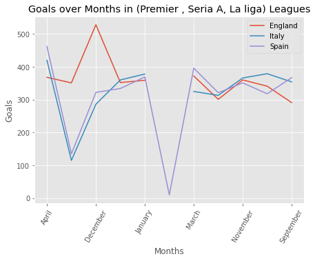

```python
# call function goal over months
goal_over_months()
```

### Percentage of goals In home and away.

```python
england_total = np.sum(england_df['home_team_goal'])+np.sum(england_df['away_team_goal'])
england_home = round(np.sum(england_df['home_team_goal']) / england_total,2)
england_away = round(np.sum(england_df['away_team_goal']) / england_total,2)
```

```python
spain_total = np.sum(spain_df['home_team_goal'])+np.sum(spain_df['away_team_goal'])
spain_home = round(np.sum(spain_df['home_team_goal']) / spain_total,2)
spain_away = round(np.sum(spain_df['away_team_goal']) / spain_total,2)
```

```python
italy_total = np.sum(italy_df['home_team_goal'])+np.sum(italy_df['away_team_goal'])
italy_home = round(np.sum(italy_df['home_team_goal']) / italy_total,2)
italy_away = round(np.sum(italy_df['away_team_goal']) / italy_total,2)
```

```python
def home_away_goals():
    X = ["Premier League" , "Serie A", "LA LIGA"]
    home = [england_home,italy_home,spain_home]
    away = [england_away,italy_away,spain_away]

    X_axis = np.arange(len(X))

    plt.bar(X_axis - 0.2, home, 0.4, label = 'Home')
    plt.bar(X_axis + 0.2, away, 0.4, label = 'Away')

    plt.xticks(X_axis, X)
    plt.xlabel("League")
    plt.ylabel("Percentage OF Goals")
    plt.title("Goals Percentage In all Leagues")
    plt.legend()
    plt.show()
```

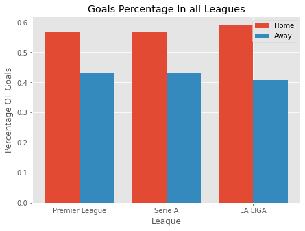

```python
# percentage of goals in home and away
home_away_goals()
```

- The player should be fit enough in his home to score goals.
- We can notice that the percentage of homes is approximately equal.

### What Is the distributions of ages In all leagues.

```python
def age_dis():
    fig, ax = plt.subplots(figsize =(8,6))
    ax.hist(df4_player['age'], alpha=0.5, label='Ages',color="#F1C40F")

    ax.set_title('Distributions of Ages In All Leagues')
    ax.set_xlabel('Ages')
    ax.set_ylabel('Count')
    ax.legend(loc='upper right')

    plt.show();
```

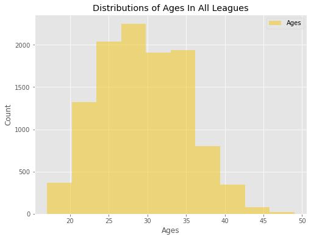

```python
# age distribtuions
age_dis()
```

- It's approximatlley normal most player falls in 25 and 35 Interval.

### Is there a relationship between pleayer height and weight.

```python
def height_weight():
    h = df4_player[['height']]
    w = df4_player[['weight']]


    plt.title("Height VS weight",fontsize=16)
    plt.xlabel("Height",fontsize=15)
    plt.ylabel("Weight",fontsize=15)


    plt.xlim(155,209)
    plt.ylim(110,250)
    plt.scatter(h,w,color = "#CD5C5C",s=100, alpha=.09);
```

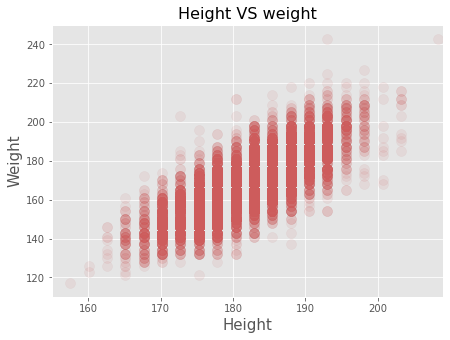

```python
# relationship between height and weight
height_weight()
```

## - There's a strong relationship between height and weight.

### Research Questions

He wants to develop his skills and ability to be able to play In Europe.

1. Is speed will help him to get more rating?
2. What skills he needs to be able to join a good team?
3. What team should he join based on what?

### What is the distributions of speed and rating?

```python
def spe_rat():
    fig, ax = plt.subplots(figsize =(8,6))
    ax.hist(df5_player_att['sprint_speed'],  label='speed')
    ax.hist(df5_player_att['overall_rating'], label='rating')
    ax.set_title('Speed & Rating')
    # ax.set_xlabel('Area')
    ax.set_ylabel('Count')
    ax.legend(loc='upper right')
    plt.show();
```

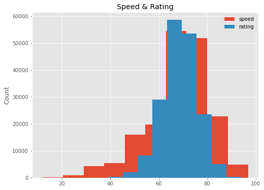

```python
# is more speed will make more rating
spe_rat()
```

- It seems that both distributions fall in the same range.
- The rating tends to be normally distributed.
- Speed tends to be left-skewed.
- The player should develop his speed to fall in 60:80 to get a higher rating.

### What skills he needs to be able to join a good team?

To answer this question we should know the average for many attributes like `finishing, dribbling, sprint_speed, acceleration,stamina`

```python
avg_finish = int(np.mean(df5_player_att['finishing']))
avg_dribbling = int(np.mean(df5_player_att['dribbling']))
avg_speed = int(np.mean(df5_player_att['sprint_speed']))
avg_accele = int(np.mean(df5_player_att['acceleration']))
avg_stamina = int(np.mean(df5_player_att['stamina']))
```

```python
def avg_attr():
    plt.title("Average Attributes",fontsize=16)
    plt.xlabel("Attributes",fontsize=15)
    plt.ylabel("Avg",fontsize=15)
    plt.bar(["Finish", "Dribbling","Speed","Acceleration","Stamina"],
            [avg_finish,avg_dribbling,avg_speed,avg_accele,avg_stamina],
            color ="#58D68D"

           );
```

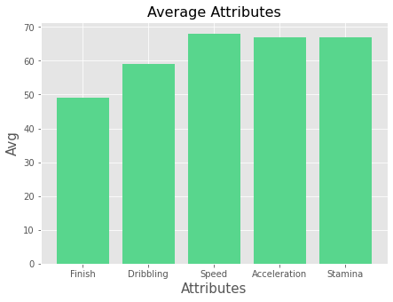

```python
# average attributes
avg_attr()
```

- The player should develop these attributes to be above them.
- He also should work on his finish to be above 50 to work In a good team.
- Speed and Acceleration are very important because the Europa League is faster than the Middle east league.

### What team should he join based on what?

he wants to choose from 3 leagues socially England, Italy, Spain he prefers to play on the Arsenal,Liverpool,Chelsea - Madrid,Barcelona,Atletico - Juventus,Roma,Milan

```python
df6_team.head(1)
```

|  | id | team_api_id | team_fifa_api_id | team_long_name | team_short_name |
| --- | --- | --- | --- | --- | --- |
| 0 | 1 | 9987 | 673.0 | KRC Genk | GEN |

```python
# I will subtract all id for those teams to filter attributes.
df6_team[df6_team['team_long_name']=='Roma']
```

|  | id | team_api_id | team_fifa_api_id | team_long_name | team_short_name |
| --- | --- | --- | --- | --- | --- |
| 136 | 20525 | 8686 | 52.0 | Roma | ROM |

```python
# I extract all id for those teams to compare each other
arsenal_id   = 9825
liverpool_id = 8650
chelsea_id   = 8455

barcelona_id = 8634
realMadrid_id= 8633
atlético_id  = 9906

milan_id   = 8564
juventus_id= 9885
roma_id    = 8686
```

```python
# get data for those teams
data_arsenal = df7_team_att.query("team_api_id == 9825")
data_liverpool = df7_team_att.query("team_api_id == 8650")
data_chelsea = df7_team_att.query("team_api_id == 8455")

data_barcelona = df7_team_att.query("team_api_id == 8634")
data_madrid = df7_team_att.query("team_api_id == 8633")
data_atletico = df7_team_att.query("team_api_id == 9906")

data_milan = df7_team_att.query("team_api_id == 8564")
data_juventus = df7_team_att.query("team_api_id == 9885")
data_roma = df7_team_att.query("team_api_id == 8686")
```

```python
# average speed teams

speed_ars = np.mean(data_arsenal['buildUpPlaySpeed'])
speed_liv = np.mean(data_liverpool['buildUpPlaySpeed'])
speed_che = np.mean(data_chelsea['buildUpPlaySpeed'])

speed_bar = np.mean(data_barcelona['buildUpPlaySpeed'])
speed_mad = np.mean(data_madrid['buildUpPlaySpeed'])
speed_atl = np.mean(data_atletico['buildUpPlaySpeed'])

speed_mil = np.mean(data_milan['buildUpPlaySpeed'])
speed_juv = np.mean(data_juventus['buildUpPlaySpeed'])
speed_rom = np.mean(data_roma['buildUpPlaySpeed'])
```

```python
def avg_buildSpeed():
    plt.title("Average BuildUpPlaySpeed",fontsize=16)
    plt.xlabel("Teams",fontsize=15)
    plt.ylabel("Avg Speed",fontsize=15)

    teams_names     = ['Arsenal','Liverpool','Chelsea' ,'Madrid','Barcelona','Atletico' ,'Juventus','Roma','Milan']
    teams_speed_avg = [speed_ars, speed_liv, speed_che, speed_mad, speed_bar, speed_atl, speed_juv, speed_rom,speed_mil]

    plt.xticks(rotation=60);
    plt.bar(teams_names,
            teams_speed_avg,
            color ="#F39C12"

           );
```

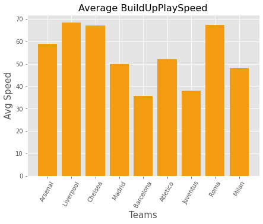

```python
# average build speed
avg_buildSpeed()
```

- Based on speed England team tend to play with higher speed.
- Spain league less speed because they tend to pass more.
- Italian leagues differ from each other but Rome looks faster.

```python
# average chanceCreationPassing
chance_ars = np.mean(data_arsenal['chanceCreationPassing'])
chance_liv = np.mean(data_liverpool['chanceCreationPassing'])
chance_che = np.mean(data_chelsea['chanceCreationPassing'])

chance_bar = np.mean(data_barcelona['chanceCreationPassing'])
chance_mad = np.mean(data_madrid['chanceCreationPassing'])
chance_atl = np.mean(data_atletico['chanceCreationPassing'])

chance_mil = np.mean(data_milan['chanceCreationPassing'])
chance_juv = np.mean(data_juventus['chanceCreationPassing'])
chance_rom = np.mean(data_roma['chanceCreationPassing'])
```

```python
def avg_chance_passing():
    plt.title("Average Chance Creation Passing",fontsize=16)
    plt.xlabel("Teams",fontsize=14)
    plt.ylabel("Avg Chances",fontsize=14)

    teams_names     = ['Arsenal','Liverpool','Chelsea' ,'Madrid','Barcelona','Atletico' ,'Juventus','Roma','Milan']
    teams_speed_avg = [chance_ars, chance_liv, chance_che, chance_mad, chance_bar, chance_atl, chance_juv, chance_rom,chance_mil]

    plt.xticks(rotation=60);
    plt.bar(teams_names,
            teams_speed_avg,
            color ="#A569BD"

           );
```

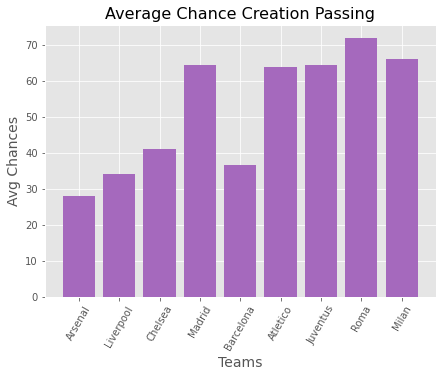

```python
avg_chance_passing()
```

- Italian teams make a lot of chances created by passing.
- Also real Madrid tends to make more chances by passing.

```python
# average chance Creation Crossing
cross_ars = np.mean(data_arsenal['chanceCreationCrossing'])
cross_liv = np.mean(data_liverpool['chanceCreationCrossing'])
cross_che = np.mean(data_chelsea['chanceCreationCrossing'])

cross_bar = np.mean(data_barcelona['chanceCreationCrossing'])
cross_mad = np.mean(data_madrid['chanceCreationCrossing'])
cross_atl = np.mean(data_atletico['chanceCreationCrossing'])

cross_mil = np.mean(data_milan['chanceCreationCrossing'])
cross_juv = np.mean(data_juventus['chanceCreationCrossing'])
cross_rom = np.mean(data_roma['chanceCreationCrossing'])
```

```python
def avg_crossing():
    plt.title("Average Chance Creation Crossing",fontsize=16)
    plt.xlabel("Teams",fontsize=14)
    plt.ylabel("Avg Chances",fontsize=14)

    teams_names     = ['Arsenal','Liverpool','Chelsea' ,'Madrid','Barcelona','Atletico' ,'Juventus','Roma','Milan']
    teams_speed_avg = [cross_ars, cross_liv, cross_che, cross_mad, cross_bar, cross_atl, cross_juv, cross_rom,cross_mil]

    plt.xticks(rotation=60);
    plt.bar(teams_names,
            teams_speed_avg,
            color ="#C0392B"

           );
```

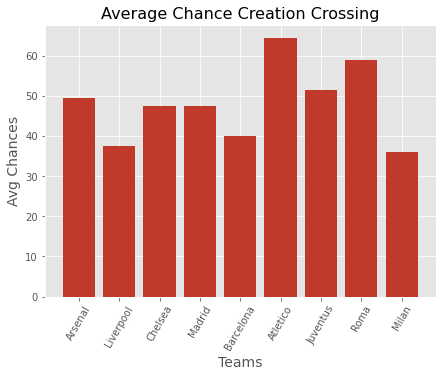

```python
avg_crossing()
```

- Rome and Atletico create more chances by crossing.
- Arsenal and Juvenuts also making more chances by crossing.

```python
# average defencePressure
cross_ars = np.mean(data_arsenal['defencePressure'])
cross_liv = np.mean(data_liverpool['defencePressure'])
cross_che = np.mean(data_chelsea['defencePressure'])

cross_bar = np.mean(data_barcelona['defencePressure'])
cross_mad = np.mean(data_madrid['defencePressure'])
cross_atl = np.mean(data_atletico['defencePressure'])

cross_mil = np.mean(data_milan['defencePressure'])
cross_juv = np.mean(data_juventus['defencePressure'])
cross_rom = np.mean(data_roma['defencePressure'])
```

```python
def avg_crossing():
    plt.title("Average Defence Pressure",fontsize=16)
    plt.xlabel("Teams",fontsize=14)
    plt.ylabel("Avg Defence",fontsize=14)

    teams_names     = ['Arsenal','Liverpool','Chelsea' ,'Madrid','Barcelona','Atletico' ,'Juventus','Roma','Milan']
    teams_speed_avg = [cross_ars, cross_liv, cross_che, cross_mad, cross_bar, cross_atl, cross_juv, cross_rom,cross_mil]

    plt.xticks(rotation=60);
    plt.bar(teams_names,
            teams_speed_avg,
            color ="#5499C7"

           );
```

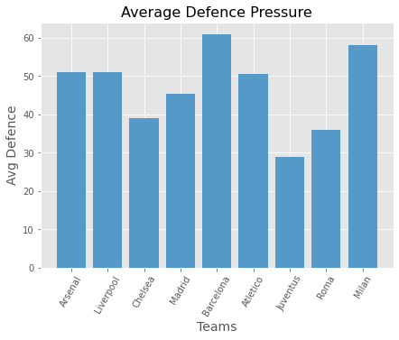

```python
avg_crossing()
```

- Barcelona didn't give you any chance to play they have a higher pressues.
- Milan comes second.
- Arsenal,Liverpool and Atletico are approximately equal pressures.

## Results: Our data suggest that

> ```
> 1. The player should develop his speed to get more ratings.
> 2. He also should develop his skills in Accelerations and speed to be above 60
> to get a good chance to play in Europe.
> 3. His finishing, dribbling, and stamina should be above 50.
> 4. If the player is curious to play in a team that depends on speed
> he should think in Liverpool, Chelsea, or Rome.
> 5. If he loves chances bypassing he should think in Madrid or Rome.
> 6. If he likes crossing so Atletico will be fit for him.
> 7. If he loves pressure, Barcelona is the best team in that.
> ```

## Limitations: There are a couple of limitations with our teams:

> ```
> 1. I don't have enough in formations about the team like goals
>        per match, winning percentage, rating of the team, the rank of the team.
> 2. Also the data doesn't contain specific information for each player
>     like his goals his assist and more.
> 3. The statistics used here are descriptions statistics, not inferential,
>     meaning that we did not create any hypothesis testing.
> 4. Cannot show the relationship between the speed of the player and his goals.
> 5. Cannot show the correlation between team possession and winning i don't have enough information.
> ```